# Homework 1

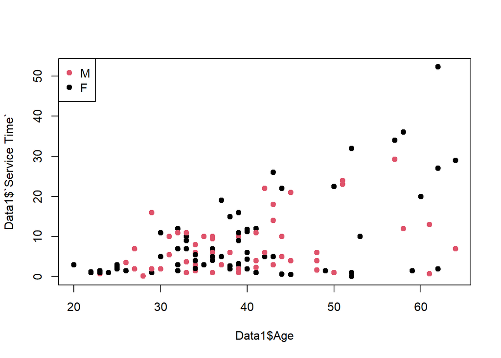

```r
plot(Data1$Age,Data1$`Service Time`, pch = 19, col = factor(Data1$Gender))
legend("topleft", legend = levels(factor(Data1$Gender)), pch = 19, col = factor(levels(factor(Data1$Gender))))
```

The graph between Age vs Service time grouped by Coworker Relationships doesnt show a pattern or trend and is more randomly spread

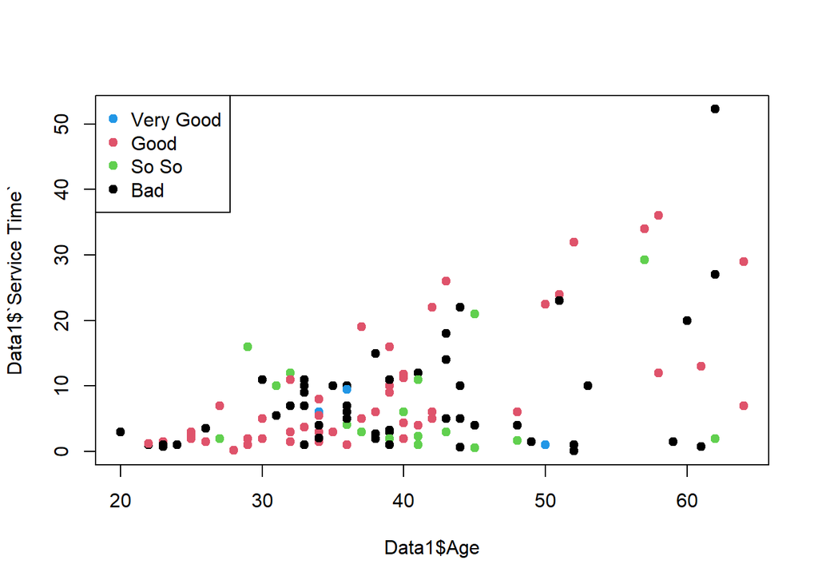

```r
plot(Data1$Age,Data1$`Service Time`, pch = 19, col = factor(Data1$`Coworker Relationships`))
legend("topleft", legend = levels(factor(Data1$`Coworker Relationships`)), pch = 19, col = factor(levels(factor(Data1$`Coworker Relationships`))))
```

The graph between Age vs Service time grouped by Promotion Likeliness shows younger and less service time are more likely to think they can be promoted while higher age and service time employees think they are very unlikely or likely

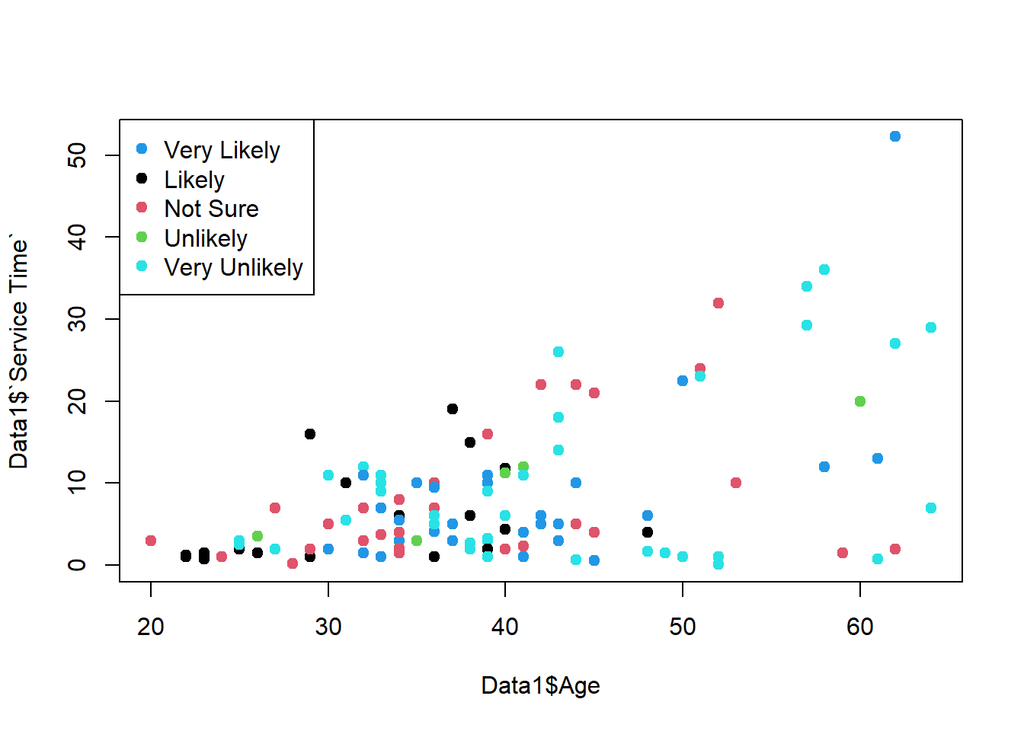

```r
plot(Data1$Age,Data1$`Service Time`, pch = 19, col = factor(Data1$`Promotion Likeliness`))
legend("topleft", legend = levels(factor(Data1$`Promotion Likeliness`)), pch = 19, col = factor(levels(factor(Data1$`Promotion Likeliness`))))
```

The graph between Age vs Service time grouped by Stay if less money doesn’t show an apparent pattern or trend

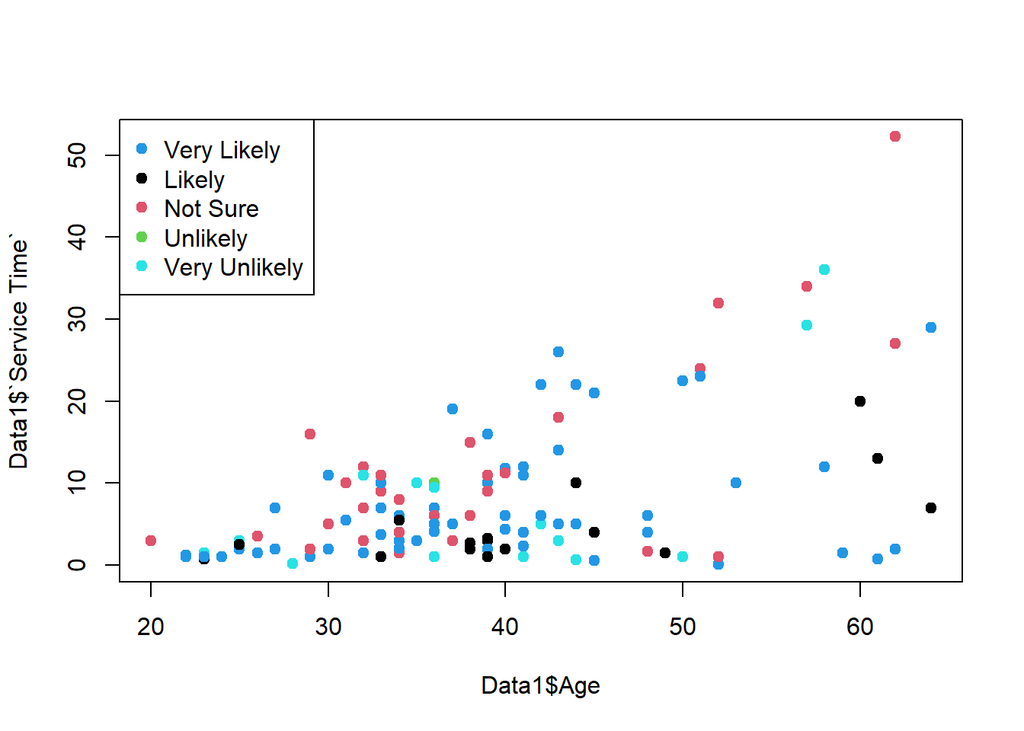

```r
plot(Data1$Age,Data1$`Service Time`, pch = 19, col = factor(Data1$`Stay if Less Money?`))
legend("topleft", legend = levels(factor(Data1$`Stay if Less Money?`)), pch = 19, col = factor(levels(factor(Data1$`Stay if Less Money?`))))
```

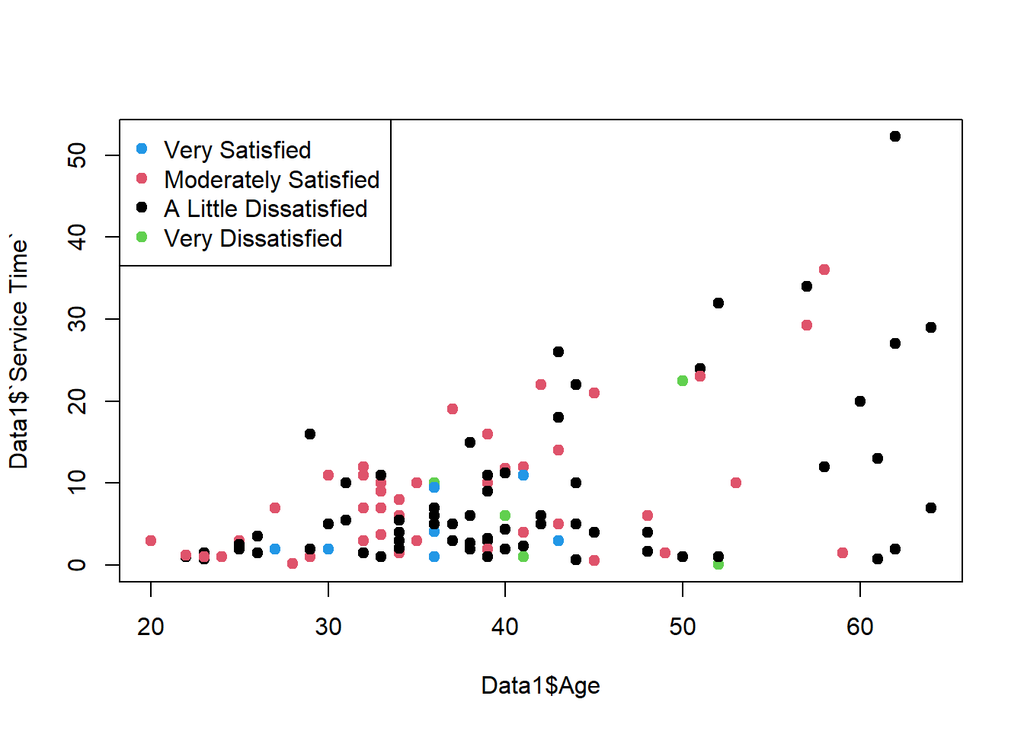

```r
plot(Data1$Age,Data1$`Service Time`, pch = 19, col = factor(Data1$`Job Satisfaction`))
legend("topleft", legend = levels(factor(Data1$`Job Satisfaction`)), pch = 19, col = factor(levels(factor(Data1$`Job Satisfaction`))))
```

Summary stats grouped by gender. Shows females are slightly older

```r
by(Data1$Age,Data1$Gender,summary)
```

```
## Data1$Gender: M
##    Min. 1st Qu.  Median    Mean 3rd Qu.    Max.
##   20.00   32.00   38.00   38.67   43.00   64.00
## ------------------------------------------------------------
## Data1$Gender: F
##    Min. 1st Qu.  Median    Mean 3rd Qu.    Max.
##   23.00   33.00   38.50   39.67   44.25   64.00
```

```r
by(Data1$`Service Time`,Data1$Age, summary)
```

```
## Data1$Age: 20
##    Min. 1st Qu.  Median    Mean 3rd Qu.    Max.
##       3       3       3       3       3       3
## ------------------------------------------------------------
## Data1$Age: 22
##    Min. 1st Qu.  Median    Mean 3rd Qu.    Max.
##   1.000   1.000   1.000   1.083   1.125   1.250
## ------------------------------------------------------------
## Data1$Age: 23
##    Min. 1st Qu.  Median    Mean 3rd Qu.    Max.
##   0.750   0.875   1.000   1.083   1.250   1.500
## ------------------------------------------------------------
## Data1$Age: 24
##    Min. 1st Qu.  Median    Mean 3rd Qu.    Max.
##       1       1       1       1       1       1
## ------------------------------------------------------------
## Data1$Age: 25
##    Min. 1st Qu.  Median    Mean 3rd Qu.    Max.
##   2.000   2.375   2.500   2.500   2.625   3.000
## ------------------------------------------------------------
## Data1$Age: 26
##    Min. 1st Qu.  Median    Mean 3rd Qu.    Max.
##     1.5     2.0     2.5     2.5     3.0     3.5
## ------------------------------------------------------------
## Data1$Age: 27
##    Min. 1st Qu.  Median    Mean 3rd Qu.    Max.
##    2.00    3.25    4.50    4.50    5.75    7.00
## ------------------------------------------------------------
## Data1$Age: 28
##    Min. 1st Qu.  Median    Mean 3rd Qu.    Max.
##    0.16    0.16    0.16    0.16    0.16    0.16
## ------------------------------------------------------------
## Data1$Age: 29
##    Min. 1st Qu.  Median    Mean 3rd Qu.    Max.
##   1.000   1.500   2.000   6.333   9.000  16.000
## ------------------------------------------------------------
## Data1$Age: 30
##    Min. 1st Qu.  Median    Mean 3rd Qu.    Max.
##     2.0     3.5     5.0     6.0     8.0    11.0
## ------------------------------------------------------------
```

[output cut: 96 more lines]

```
## Data1$Age: 60
##    Min. 1st Qu.  Median    Mean 3rd Qu.    Max.
##      20      20      20      20      20      20
## ------------------------------------------------------------
## Data1$Age: 61
##    Min. 1st Qu.  Median    Mean 3rd Qu.    Max.
##   0.750   3.812   6.875   6.875   9.938  13.000
## ------------------------------------------------------------
## Data1$Age: 62
##    Min. 1st Qu.  Median    Mean 3rd Qu.    Max.
##    1.91   14.46   27.00   27.05   39.62   52.25
## ------------------------------------------------------------
## Data1$Age: 64
##    Min. 1st Qu.  Median    Mean 3rd Qu.    Max.
##     7.0    12.5    18.0    18.0    23.5    29.0
```